[output not shown]

# Evaluation metrics

[figure not shown]

```python
from pyannote.core import Annotation, Segment
reference = Annotation()
reference[Segment(0, 1)] = 'SHELDON'
reference[Segment(1, 2)] = 'PENNY'
reference[Segment(3, 4)] = 'LEONARD'
reference[Segment(4, 6)] = 'SHELDON'
reference
```

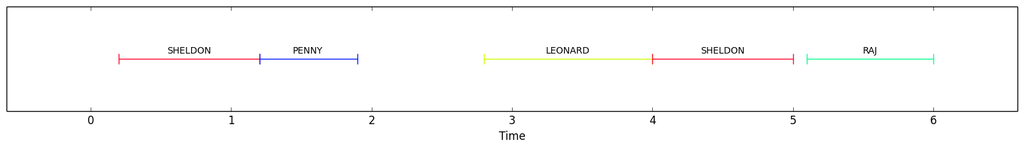

```python
hypothesis = Annotation()
hypothesis[Segment(0.2, 1.2)] = 'SHELDON'
hypothesis[Segment(1.2, 1.9)] = 'PENNY'
hypothesis[Segment(2.8, 4)] = 'LEONARD'
hypothesis[Segment(4, 5)] = 'SHELDON'
hypothesis[Segment(5.1, 6)] = 'RAJ'
hypothesis
```

## Evaluation of speech activity detection

Speech activity detection results are reported using three complementary evaluation metrics.

The **Detection error rate** (DER) is the ratio of the duration incorrectly classified as speech (false alarm) or non-speech (missed detection) over the total duration of speech in the episode:

$\displaystyle \text{DER} = \frac{\text{miss} + \text{fa}}{\text{total}}$

where:

- $\text{total}$ is the total duration of speech according to the reference annotation,
- $\text{miss}$ is the total duration of segments incorrectly classified as non-speech,
- $\text{fa}$ is the total duration of segments incorrectly classified as speech,

```python
from pyannote.metrics.detection import DetectionErrorRate
detectionErrorRate = DetectionErrorRate()
d = detectionErrorRate(reference, hypothesis)
print 'Detection error rate: {d:.1f}%'.format(d=100*d)
```

```
Detection error rate: 12.0%
```

Using **detailed=**True, we get more details:

```python
details = detectionErrorRate(reference, hypothesis, detailed=True)
details
```

```
{u'detection error rate': 0.11999999999999997,
 u'false alarm': 0.20000000000000018,
 u'miss': 0.39999999999999974,
 u'total': 5.0}
```

**Precision** is the ratio of the total duration reported as speech that is indeed annotated as speech in the reference annotation.

```python
from pyannote.metrics.detection import DetectionPrecision
detectionPrecision = DetectionPrecision()
p = detectionPrecision(reference, hypothesis)
print 'Detection precision: {p:.1f}%'.format(p=100*p)
```

```
Detection precision: 95.8%
```

**Recall** is the ratio of the total duration of speech according to the reference annotation that is is indeed detected as speech in the hypothesis.

```python
from pyannote.metrics.detection import DetectionRecall
detectionRecall = DetectionRecall()
r = detectionRecall(reference, hypothesis)
print 'Detection recall: {r:.1f}%'.format(r=100*r)
```

```
Detection recall: 92.0%
```

```python
from pyannote.metrics import f_measure
print 'Detection f-measure: {f:.1f}%'.format(f=100*f_measure(p, r))
```

```
Detection f-measure: 93.9%
```

## Evaluation of speaker identification

Speaker identification results are reported using **Identification error rate** (IER), defined as follows:

$\displaystyle \text{IER} = \frac{\text{miss} + \text{fa} + \text{confusion}}{\text{total}}$

where

- $\text{total}$ is the total duration of speech according to the reference annotation,
- $\text{miss}$ is the total duration of segments incorrectly classified as non-speech,
- $\text{fa}$ is the total duration of segments incorrectly classified as speech,
- $\text{confusion}$ is the total duration of \emph{speech} segments whose detected label is incorrect.

In other words, it is a compound metric that accounts for both speech turns detection and identification errors.

```python
from pyannote.metrics.identification import IdentificationErrorRate
identificationErrorRate = IdentificationErrorRate()
i = identificationErrorRate(reference, hypothesis)
print 'Identification error rate: {i:.1f}%'.format(i=100*i)
```

```
Identification error rate: 34.0%
```

Using **detailed=**True, we get more details:

```python
identificationErrorRate(reference, hypothesis, detailed=True)
```

```
{u'confusion': 1.1000000000000003,
 u'correct': 3.5,
 u'false alarm': 0.20000000000000018,
 u'identification error rate': 0.34,
 u'missed detection': 0.39999999999999974,
 u'total': 5.0}
```

## Bonus

Standard precision and recall metrics are also available for identification.

```python
from pyannote.metrics.identification import IdentificationPrecision
precision = IdentificationPrecision()
p = precision(reference, hypothesis)
print 'Identification precision: {p:.1f}%'.format(p=100*p)
```

```
Identification precision: 72.9%
```

```python
from pyannote.metrics.identification import IdentificationRecall
recall = IdentificationRecall()
r = recall(reference, hypothesis)
print 'Identification recall: {r:.1f}%'.format(r=100*r)
```

```
Identification recall: 70.0%
```

An in-depth analysis or identification errors is also available.

```python
from pyannote.metrics.errors.identification import IdentificationErrorAnalysis
identificationErrorAnalysis = IdentificationErrorAnalysis()
identificationErrorAnalysis.matrix(reference, hypothesis)
```

|  | reference | hypothesis | correct | confusion | false alarm | missed detection | LEONARD | PENNY | RAJ | SHELDON |
| --- | --- | --- | --- | --- | --- | --- | --- | --- | --- | --- |
| LEONARD | 1 | 1.2 | 1.0 | 0.0 | 0.2 | 0.0 | 1 | 0.0 | 0.0 | 0.0 |
| PENNY | 1 | 0.7 | 0.7 | 0.2 | 0.0 | 0.1 | 0 | 0.7 | 0.0 | 0.2 |
| SHELDON | 3 | 2.0 | 1.8 | 0.9 | 0.0 | 0.3 | 0 | 0.0 | 0.9 | 1.8 |

- column **reference** contains the speech duration of each speaker according to the reference
- column **hypothesis** contains the speech duration of each speaker according to the hypothesis
- column **correct** contains the duration of correct identification for each speaker
- etc...
- last four columns provide the detailed **confusion matrix**

Finally, here is the list of errors, sorted from the most to the least frequent, along with their duration.

```python
identificationErrorAnalysis.annotation(reference, hypothesis).chart()
```

```
[((u'correct', 'SHELDON', 'SHELDON'), 1.8),
 ((u'correct', 'LEONARD', 'LEONARD'), 1),
 ((u'confusion', 'SHELDON', 'RAJ'), 0.9000000000000004),
 ((u'correct', 'PENNY', 'PENNY'), 0.7),
 ((u'missed detection', 'SHELDON', None), 0.29999999999999966),
 ((u'false alarm', None, 'LEONARD'), 0.20000000000000018),
 ((u'confusion', 'PENNY', 'SHELDON'), 0.19999999999999996),
 ((u'missed detection', 'PENNY', None), 0.10000000000000009)]
```